# Advanced Tree Models – Bagging, Random Forests, and Boosting

Shaobo Li

April, 2019

In this lab, we will cover some state-of-the-art techniques in the framework of tree models. We use the same datasets as in previous lab, Boston Housing data and Credit Scoring data.

```r
# load Boston data
library(MASS)
library(tidyverse)
data(Boston)
index <- sample(nrow(Boston),nrow(Boston)*0.70)
boston.train <- Boston[index,]
boston.test <- Boston[-index,]

# load credit card data
credit.data <- read.csv("http://homepages.uc.edu/~lis6/DataMining/Data/credit_default.csv", header=T)
credit.data<- rename(credit.data, default=default.payment.next.month)
# convert categorical data to factor
credit.data$SEX<- as.factor(credit.data$SEX)
credit.data$EDUCATION<- as.factor(credit.data$EDUCATION)
credit.data$MARRIAGE<- as.factor(credit.data$MARRIAGE)
# random splitting
index <- sample(nrow(credit.data),nrow(credit.data)*0.80)
credit.train = credit.data[index,]
credit.test = credit.data[-index,]

# load MNIST data
digit<- data.matrix(read_csv("https://www.dropbox.com/s/ulujvi2a4ykfzju/train.csv?dl=1"))
# random splitting
index<- sample(1:nrow(digit), 0.6*nrow(digit))
train<- digit[index,]
test<- digit[-index,]
# standardize X
train.x <- train[,-1] #remove 'label' column
test.x<- test[,-1]
train.y <- train[,1] #label column
test.y<- test[,1]
train.x <- train.x/255
test.x <- test.x/255
```

# Bagging

*Bagging* stands for Bootstrap and Aggregating. It employs the idea of bootstrap but the purpose is not to study bias and standard errors of estimates. Instead, the goal of Bagging is to improve prediction accuracy. It fits a tree for each bootsrap sample, and then aggregate the predicted values from all these different trees. For more details, you may look at [Wikepedia](https://en.wikipedia.org/wiki/Bootstrap_aggregating), or you can find the original paper Leo Breiman (1996).

An available R package, `ipred`, provides functions to perform Bagging. You need to install this package if you didn’t do it before.

```r
library(ipred)
```

## Bagging for regression tree.

Fit tree with bagging on Boston training data, and calculate MSE on testing sample.

```r
boston.bag<- bagging(medv~., data = boston.train, nbagg=100)
boston.bag
```

```
##
## Bagging regression trees with 100 bootstrap replications
##
## Call: bagging.data.frame(formula = medv ~ ., data = boston.train, nbagg = 100)
```

Prediction on testing sample.

```r
boston.bag.pred<- predict(boston.bag, newdata = boston.test)
mean((boston.test$medv-boston.bag.pred)^2)
```

```
## [1] 24.60431
```

Comparing with a single tree.

```r
library(rpart)
boston.tree<- rpart(medv~., data = boston.train)
boston.tree.pred<- predict(boston.tree, newdata = boston.test)
mean((boston.test$medv-boston.tree.pred)^2)
```

```
## [1] 27.47015
```

How many trees are good?

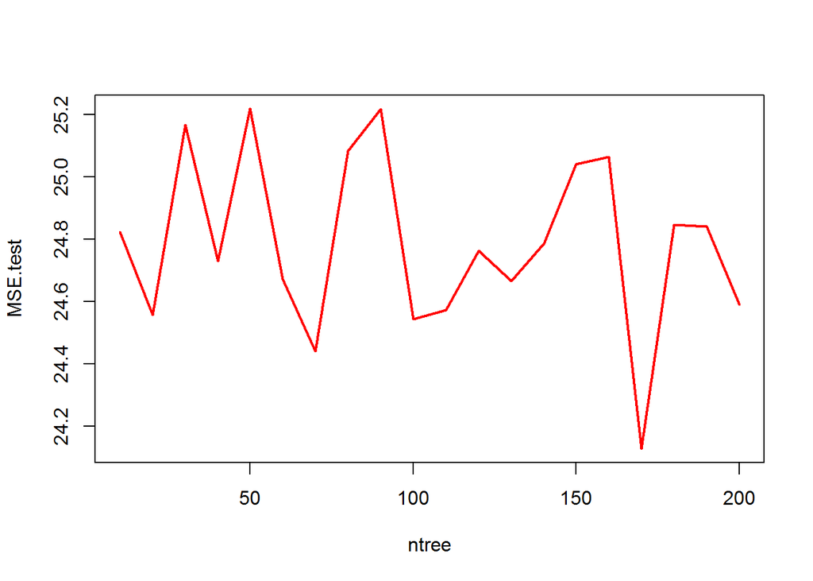

```r
ntree<- c(seq(10, 200, 10))
MSE.test<- rep(0, length(ntree))
for(i in 1:length(ntree)){
  boston.bag1<- bagging(medv~., data = boston.train, nbagg=ntree[i])
  boston.bag.pred1<- predict(boston.bag1, newdata = boston.test)
  MSE.test[i]<- mean((boston.test$medv-boston.bag.pred1)^2)
}
plot(ntree, MSE.test, type = 'l', col=2, lwd=2)
```

By fitting the Bagging multiple times and predicting the testing sample, we can draw the following boxplot to show the variance of the prediction error at different number of trees.

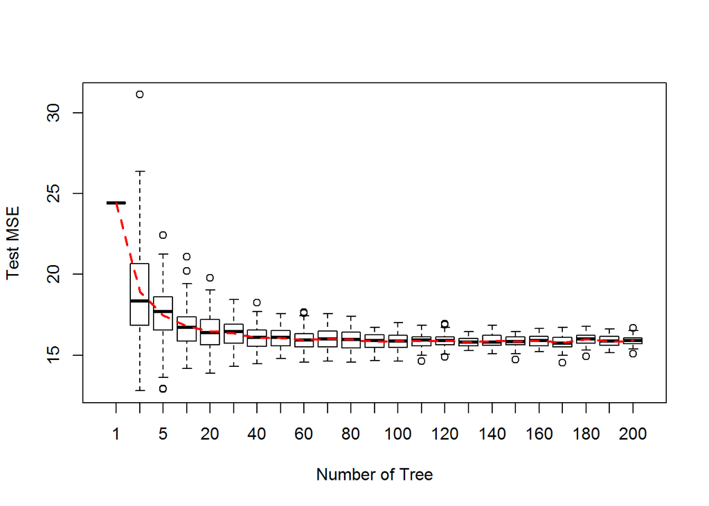

## Out-of-bag (OOB) prediction

The out-of-bag prediction is similar to LOOCV. We use full sample. In every bootstrap, the unused sample serves as testing sample, and testing error is calculated. In the end, OOB error, root mean squared error by default, is obtained

```r
boston.bag.oob<- bagging(medv~., data = boston.train, coob=T, nbagg=100)
boston.bag.oob
```

```
##
## Bagging regression trees with 100 bootstrap replications
##
## Call: bagging.data.frame(formula = medv ~ ., data = boston.train, coob = T,
##     nbagg = 100)
##
## Out-of-bag estimate of root mean squared error:  3.9392
```

## Bagging for classification tree.

```r
credit.bag<- bagging(as.factor(default)~., data = credit.train, nbagg=100,
                     method="class", parms=list(loss=matrix(c(0,5,1,0), nrow=2)))
#credit.bag.pred<- predict(credit.bag, newdata = credit.train, type="prob")[,2]
credit.bag.pred.test<- predict(credit.bag, newdata = credit.test, type="prob")[,2]
```

The classification results are generated by specifying `type="class"`.

```r
credit.bag.pred.test<- predict(credit.bag, newdata = credit.test, type="class")
table(credit.test$default, credit.bag.pred.test, dnn = c("True", "Pred"))
```

```
##     Pred
## True    0    1
##    0 1753  116
##    1  332  199
```

```r
credit.rpart <- rpart(formula = default ~ ., data = credit.train,
                      method = "class", parms=list(loss=matrix(c(0,5,1,0), nrow=2)))
credit.test.pred.tree1<- predict(credit.rpart, credit.test, type="class")
table(credit.test$default, credit.test.pred.tree1, dnn=c("Truth","Predicted"))
```

```
##      Predicted
## Truth    0    1
##     0 1139  730
##     1  126  405
```

Back to top

# Random Forests

Random forest is an extension of Bagging, but it makes significant improvement in terms of prediction. The idea of random forests is to randomly select $m$ out of $p$ predictors as candidate variables for each split in each tree. Commonly, $m=\sqrt{p}$. The reason of doing this is that it can *decorrelates* the trees such that it reduces variance when we aggregate the trees. You may refer [Wikipedia](https://en.wikipedia.org/wiki/Random_forest) and the [tutorial](https://www.stat.berkeley.edu/~breiman/RandomForests/cc_home.htm) on the author’s website.

## Random Forest for Regression

We start with Boston Housing data.

```r
library(randomForest)
boston.rf<- randomForest(medv~., data = boston.train, importance=TRUE)
boston.rf
```

```
##
## Call:
##  randomForest(formula = medv ~ ., data = boston.train, importance = TRUE)
##                Type of random forest: regression
##                      Number of trees: 500
## No. of variables tried at each split: 4
##
##           Mean of squared residuals: 9.326951
##                     % Var explained: 89.12
```

By default, $m=p/3$ for regression tree, and $m=\sqrt{p}$ for classification problem. You can change it by specifying `mtry=`. You can also specify number of trees by `ntree=`. The default is 500. The argument `importance=TRUE` allows us to see the variable imporatance.

```r
boston.rf$importance
```

```
##            %IncMSE IncNodePurity
## crim     7.9710944    1984.78722
## zn       0.6091246     255.58932
## indus    7.3363313    2185.07308
## chas     0.1496178      83.53703
## nox      8.4204370    1601.71959
## rm      36.7469713    9149.64461
## age      3.0277057     669.69174
## dis      6.0040978    1433.84949
## rad      1.7086938     331.54768
## tax      3.9072301    1078.33895
## ptratio  7.2591667    2040.24780
## black    1.9814220     636.69426
## lstat   48.6550744    8467.46321
```

The MSR is MSE of *out-of-bag* prediction (recall the OOB in bagging). The fitted randomForest actually saves all OOB errors for each `ntree` value from 1 to 500. We can make a plot to see how the OOB error changes with different `ntree`.

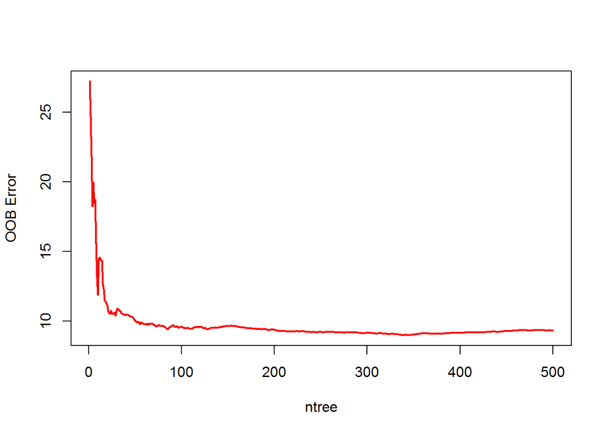

```r
plot(boston.rf$mse, type='l', col=2, lwd=2, xlab = "ntree", ylab = "OOB Error")
```

Prediction on the testing sample.

```r
boston.rf.pred<- predict(boston.rf, boston.test)
mean((boston.test$medv-boston.rf.pred)^2)
```

```
## [1] 17.65428
```

```r
oob.err<- rep(0, 13)
test.err<- rep(0, 13)
for(i in 1:13){
  fit<- randomForest(medv~., data = boston.train, mtry=i)
  oob.err[i]<- fit$mse[500]
  test.err[i]<- mean((boston.test$medv-predict(fit, boston.test))^2)
  cat(i, " ")
}
```

```
## 1  2  3  4  5  6  7  8  9  10  11  12  13
```

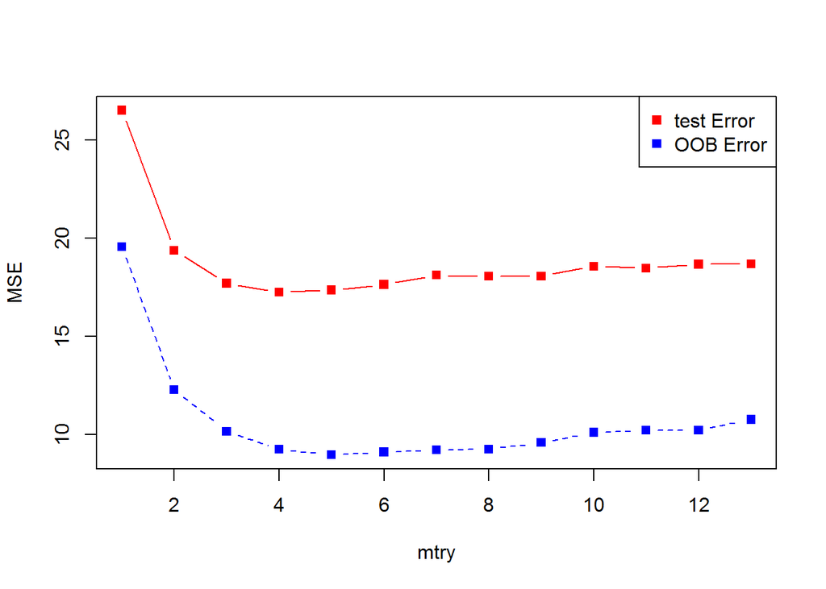

```r
matplot(cbind(test.err, oob.err), pch=15, col = c("red", "blue"), type = "b", ylab = "MSE", xlab = "mtry")
legend("topright", legend = c("test Error", "OOB Error"), pch = 15, col = c("red", "blue"))
```

#### Exercise: Create a plot displaying the test error across `ntree=`1, …, 500, and `mtry=` 1, …, 13. (You can draw 13 lines in different color representing each $m$).

## Random Forest for Classification

```r
credit.rf<- randomForest(as.factor(default)~., data = credit.train, classwt=c(5,1)) # classwt does not change the results
credit.rf
```

```
##
## Call:
##  randomForest(formula = as.factor(default) ~ ., data = credit.train,      classwt = c(5, 1))
##                Type of random forest: classification
##                      Number of trees: 500
## No. of variables tried at each split: 4
##
##         OOB estimate of  error rate: 18.35%
## Confusion matrix:
##      0   1 class.error
## 0 7075 424  0.05654087
## 1 1338 763  0.63683960
```

We can again easily plot the error rate vs. ntree. However, as far as I know, `randomForest` does not support asymmetric loss either. So it always uses the overall misclassification rate as the error.

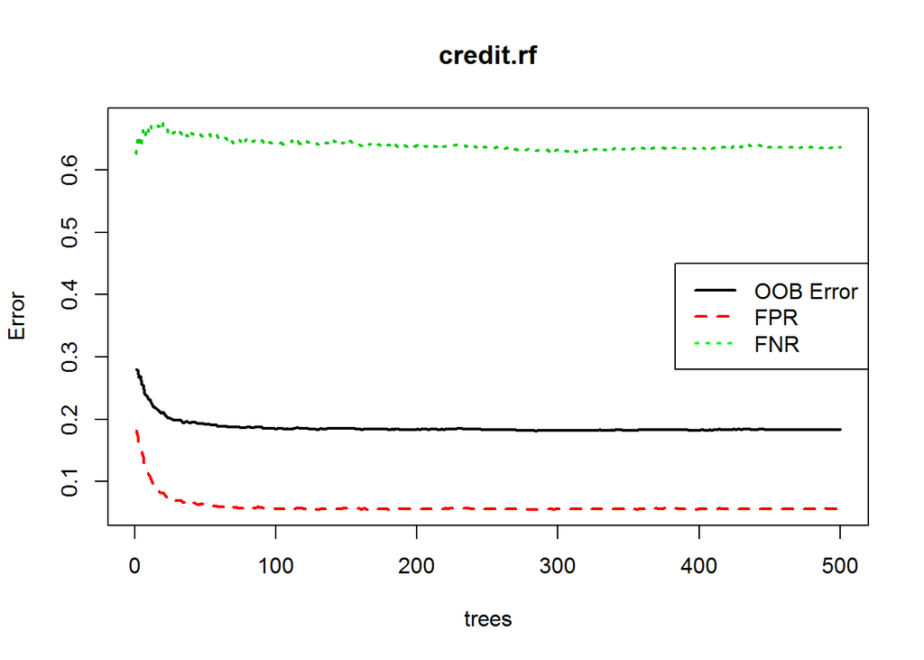

```r
plot(credit.rf, lwd=rep(2, 3))
legend("right", legend = c("OOB Error", "FPR", "FNR"), lwd=rep(2, 3), lty = c(1,2,3), col = c("black", "red", "green"))
```

As we can see, the FNR is very high, just as the confusion matrix. For prediction purpose, nevertheless, we can use `type="prob"` to get predicted probability and then find optimal cut-off. We can use sample proportion as optimal cutoff.

#### Prediction

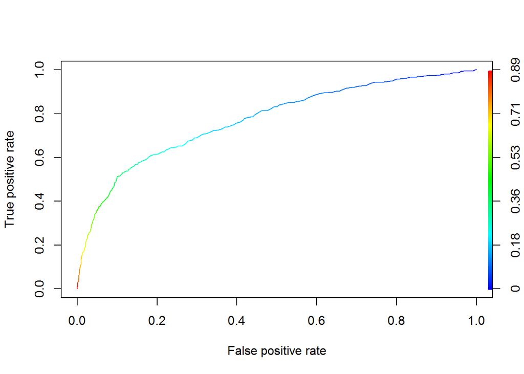

```r
credit.rf.pred<- predict(credit.rf, newdata=credit.test, type = "prob")[,2]
library(ROCR)
pred <- prediction(credit.rf.pred, credit.test$default)
perf <- performance(pred, "tpr", "fpr")
plot(perf, colorize=TRUE)
```

```r
#Get the AUC
unlist(slot(performance(pred, "auc"), "y.values"))
```

```
## [1] 0.772848
```

Below is the confusion matrix

```r
credit.rf.class.test<- (credit.rf.pred>mean(credit.train$default))*1
table(credit.test$default, credit.rf.class.test, dnn = c("True", "Pred"))
```

```
##     Pred
## True    0    1
##    0 1373  496
##    1  182  349
```

Back to top

# Boosting

Boosting builds a number of small trees, and each time, the response is the residual from last tree. It is a sequential procedure. We use `gbm` package to build boosted trees.

## Boosting for regression trees

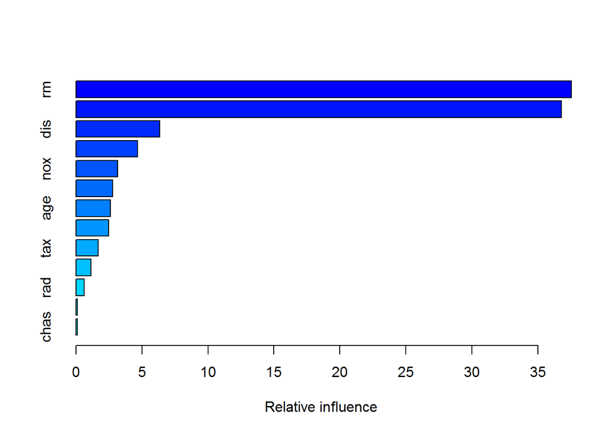

```
##             var    rel.inf
## rm           rm 37.5348680
## lstat     lstat 36.7755337
## dis         dis  6.3513309
## crim       crim  4.6634946
## nox         nox  3.1680804
## black     black  2.7852108
## age         age  2.5923270
## ptratio ptratio  2.4749335
## tax         tax  1.6859122
## indus     indus  1.1372597
## rad         rad  0.6117681
## zn           zn  0.1099943
## chas       chas  0.1092867
```

```r
library(gbm)
?gbm
boston.boost<- gbm(medv~., data = boston.train, distribution = "gaussian", n.trees = 10000, shrinkage = 0.01, interaction.depth = 8)
summary(boston.boost)
```

Note that we need to specify `distribution = "gaussian"` if we are working on regression tree. The default is *Bernoulli* distribution for binary classification problem. `n.trees` is the number of small trees we fit. We need to choose this parameter carefully because it may results in overfitting if the number is too large. `shrinkage` is another tuning parameter that controls how much contribution each tree makes. `interaction.depth` is how many splits of each tree we want. All those tuning parameters can be chosen from cross-validation. The idea is that we don’t want overfitting.

The fitted boosted tree also gives the relation between response and each predictor.

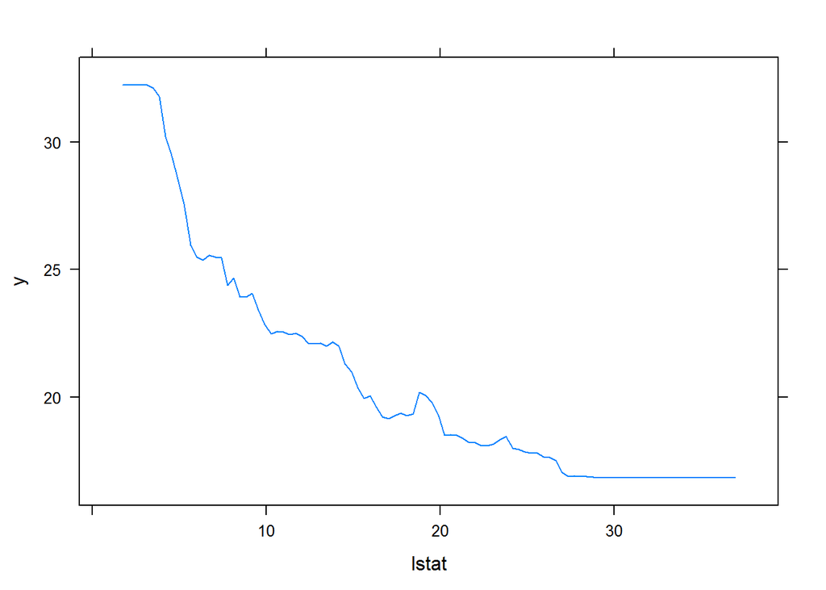

```r
par(mfrow=c(1,2))
plot(boston.boost, i="lstat")
```

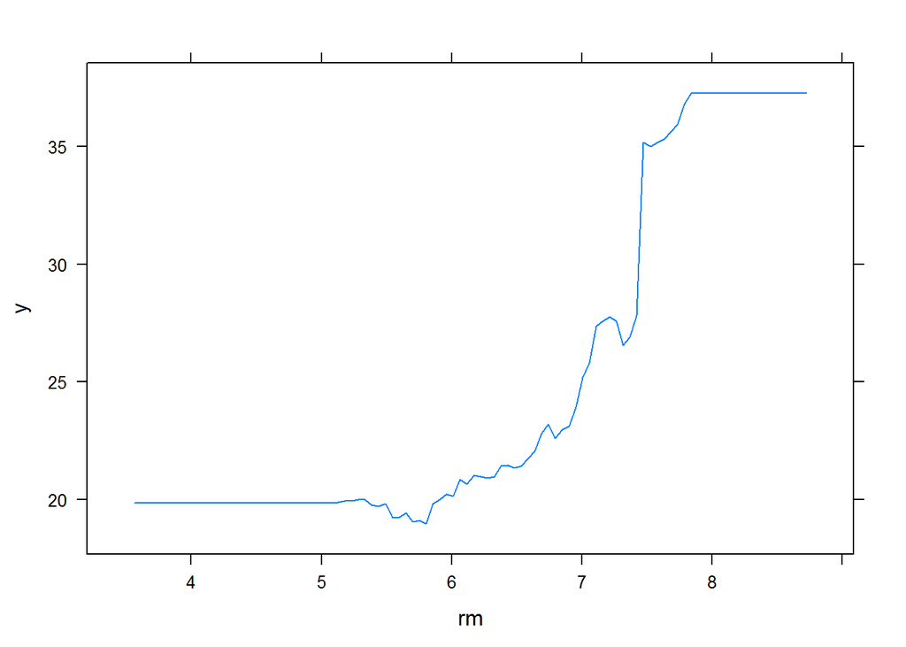

```r
plot(boston.boost, i="rm")
```

Prediction on testing sample.

```r
boston.boost.pred.test<- predict(boston.boost, boston.test, n.trees = 10000)
mean((boston.test$medv-boston.boost.pred.test)^2)
```

```
## [1] 15.4263
```

We can investigate how the testing error changes with different number of trees.

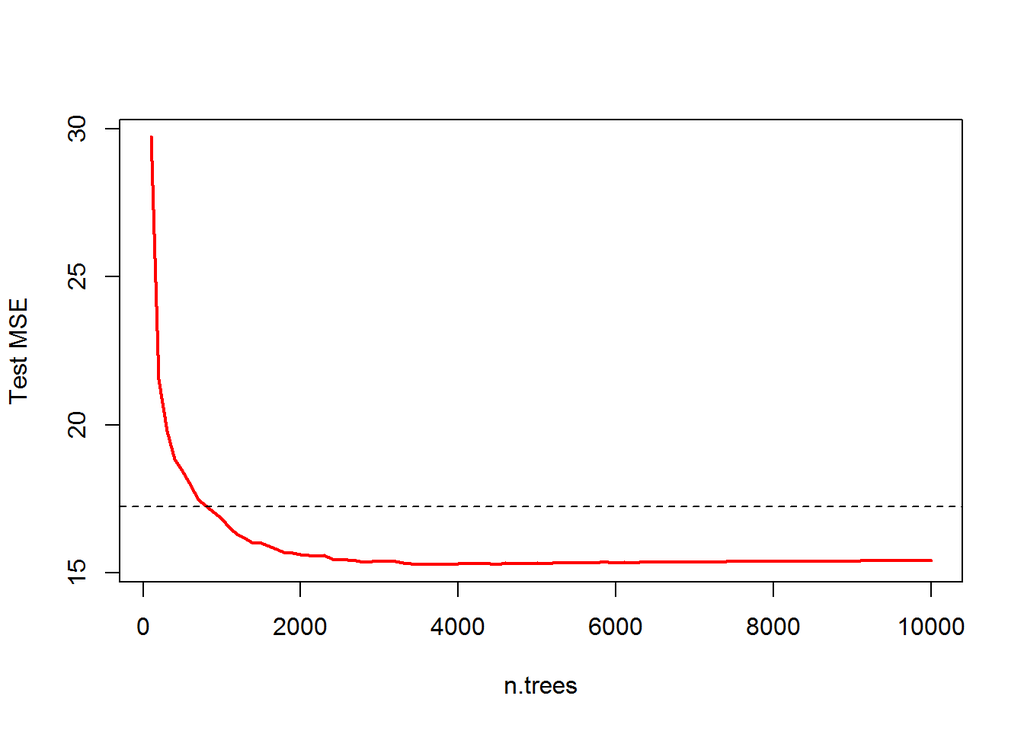

```r
par(mfrow=c(1,1))
ntree<- seq(100, 10000, 100)
predmat<- predict(boston.boost, newdata = boston.test, n.trees = ntree)
err<- apply((predmat-boston.test$medv)^2, 2, mean)
plot(ntree, err, type = 'l', col=2, lwd=2, xlab = "n.trees", ylab = "Test MSE")
abline(h=min(test.err), lty=2)
```

The horizontal line is the best prediction error from random forests we obtained earlier.

## Boosting for classification trees

#### Modeling

```r
credit.boost<- gbm(default~., data = credit.train, distribution = "bernoulli",
                   n.trees = 5000, cv.folds = 5, n.cores = 5)
```

The arguement `distribution` is to specify the type of likelihood function, `n.tree` is to specify the maximum number of trees, `cv.folds` is optional. We use cross-validation to choose the best number of trees. Recall that Boosting can easily overfit the data. The last argument is to specify the number of cores to be used for parallel computing.

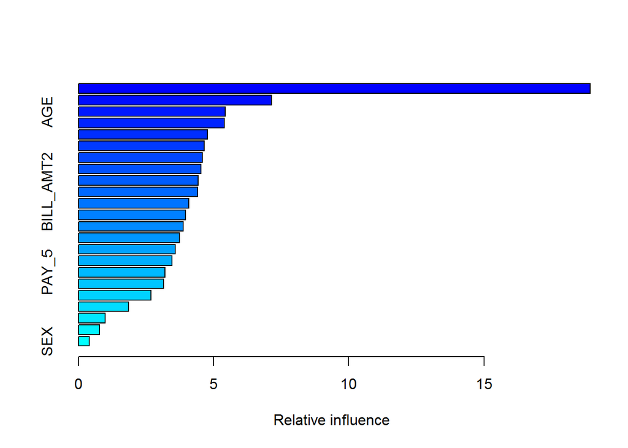

```
##                 var    rel.inf
## PAY_0         PAY_0 18.9282397
## BILL_AMT1 BILL_AMT1  7.1370892
## AGE             AGE  5.4238497
## BILL_AMT5 BILL_AMT5  5.3913795
## BILL_AMT4 BILL_AMT4  4.7791805
## PAY_2         PAY_2  4.6469379
## BILL_AMT6 BILL_AMT6  4.5897917
## PAY_AMT1   PAY_AMT1  4.5316988
## LIMIT_BAL LIMIT_BAL  4.4298643
## BILL_AMT2 BILL_AMT2  4.4024471
## BILL_AMT3 BILL_AMT3  4.0835025
## PAY_AMT3   PAY_AMT3  3.9668892
## PAY_AMT2   PAY_AMT2  3.8727588
## PAY_AMT6   PAY_AMT6  3.7375702
## PAY_4         PAY_4  3.5797443
## PAY_3         PAY_3  3.4607071
## PAY_5         PAY_5  3.2001251
## PAY_AMT4   PAY_AMT4  3.1414387
## PAY_AMT5   PAY_AMT5  2.6727435
## PAY_6         PAY_6  1.8540029
## MARRIAGE   MARRIAGE  0.9861379
## EDUCATION EDUCATION  0.7804787
## SEX             SEX  0.4034227
```

```r
# relative influence
summary(credit.boost)
```

Below is the figure of cross-validation to choose the optimal number of trees.

```r
best.iter <- (gbm.perf(credit.boost, method = "cv"))
```

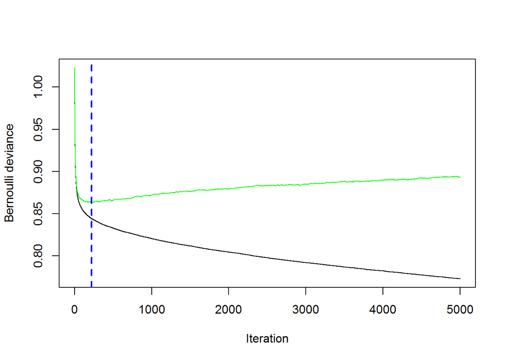

```r
best.iter
```

```
## [1] 223
```

#### Prediction

```r
# predicted probability
pred.credit.boost<- predict(credit.boost, newdata = credit.test, n.trees = best.iter, type="response")
# AUC
pred <- prediction(pred.credit.boost, credit.test$default)
# perf <- performance(pred, "tpr", "fpr")
# plot(perf, colorize=TRUE)
unlist(slot(performance(pred, "auc"), "y.values"))
```

```
## [1] 0.7851903
```

The predicted value is the probability if we specify `type="response"`, as in logistic regression.

Below we show the confusion matrix using the cutoff as the sample proportion.

```r
pred.credit.boost.class<- (pred.credit.boost>mean(credit.train$default))*1
table(credit.test$default, pred.credit.boost.class, dnn = c("True", "Pred"))
```

```
##     Pred
## True    0    1
##    0 1540  329
##    1  206  325
```

#### Compare with logit model

```r
#Fit logistic regression model
credit.glm<- glm(default~., data = credit.train, family=binomial)
pred.glm<- predict(credit.glm, credit.test, type="response")
# AUC
pred <- prediction(pred.glm, credit.test$default)
unlist(slot(performance(pred, "auc"), "y.values"))
```

```
## [1] 0.719748
```

```r
#Get binary prediction
credit.test.pred.glm<- (pred.glm>mean(credit.train$default))*1
#Confusion matrix
table(credit.test$default, credit.test.pred.glm, dnn=c("True","Pred"))
```

```
##     Pred
## True    0    1
##    0 1275  594
##    1  186  345
```

Back to top

# XGboost

## XGboost for regression

```r
library(xgboost)
fit.xgboost.reg<- xgboost(data = as.matrix(boston.train[,-14]), label = boston.train[,14], max.depth = 4, eta = 0.1,
                          nthread = 1, nrounds = 100, objective = "reg:linear", verbose = 0)
```

#### Cross-validation

How many trees are good? What value of learning rate is good? We can use cross-validation to determine these tuning parameters.

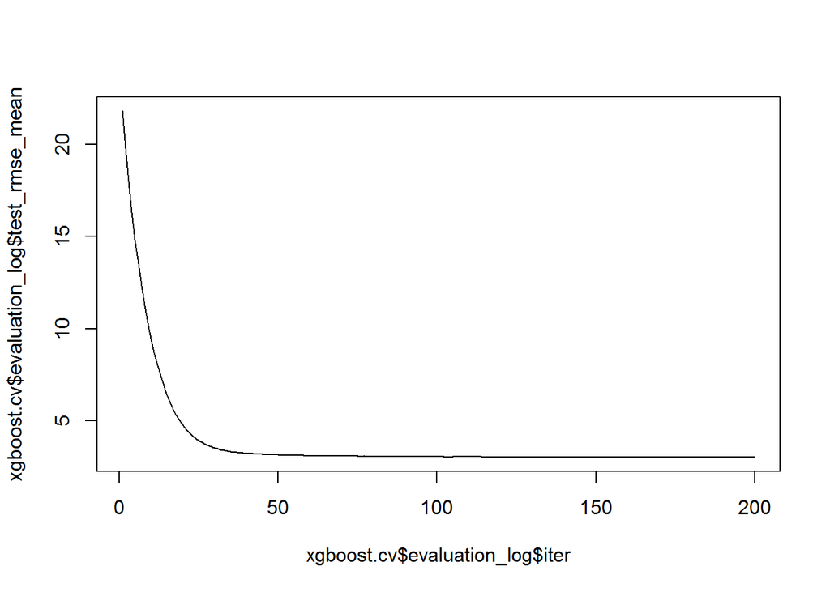

```r
xgboost.cv<- xgb.cv(data = as.matrix(boston.train[,-14]), label = boston.train[,14], max.depth = 4, eta = 0.1,
                    nfold=10, nthread = 4, nrounds = 200, objective = "reg:linear", verbose = 0)
plot(xgboost.cv$evaluation_log$iter, xgboost.cv$evaluation_log$test_rmse_mean, type='l')
```

```r
#print(xgboost.cv)
```

The performance stays the same after 100 iterations. We choose `nrounds=100` and use `xgboost()` to fit the model. You may also grid search learning rate `eta` using the similar way.

#### Prediction

```r
pred.xgboost<- predict(fit.xgboost.reg, newdata = as.matrix(boston.test[,-14]))
mean((boston.test$medv-pred.xgboost)^2)
```

```
## [1] 14.20539
```

## XGboost for classification

```r
ptm <- proc.time()
fit.xgboost.class<- xgboost(data = model.matrix(~., credit.train[,-24])[,-1], label = credit.train[,24],
                            eta = 0.1, nthread = 5, nrounds = 100, objective = "binary:logistic", verbose = 0)
proc.time()-ptm
```

```
##    user  system elapsed
##    2.36    0.16    0.73
```

#### Prediction

```r
pred.credit.xgboost<- predict(fit.xgboost.class, newdata = model.matrix(~., credit.test[,-24])[,-1])
# AUC
pred <- prediction(pred.credit.xgboost, credit.test$default)
# perf <- performance(pred, "tpr", "fpr")
# plot(perf, colorize=TRUE)
unlist(slot(performance(pred, "auc"), "y.values"))
```

```
## [1] 0.7796787
```

#### Confusion matrix

Below we show the confusion matrix using the cutoff as the sample proportion.

```r
pred.credit.xgboost.class<- (pred.credit.xgboost>mean(credit.train$default))*1
table(credit.test$default, pred.credit.xgboost.class, dnn = c("True", "Pred"))
```

```
##     Pred
## True    0    1
##    0 1485  384
##    1  193  338
```

### XGboost for large dataset – MNIST data

We can’t see the advantage of XGboost for above example (small data). It even takes longer than `gbm()`. However, the fast computing speed can be seen for large scale data analysis.

```r
ptm <- proc.time()
xgboost.digit.fit<- xgboost(data = train.x, label = train.y, eta = 0.1,  num_class=10,
                    nthread = 10, nrounds = 100, objective = "multi:softmax", verbose = 0)
proc.time()-ptm
```

```
##    user  system elapsed
## 1296.48    9.65  208.64
```

```r
xgboost.digit.pred = predict(xgboost.digit.fit, test.x)
mean(xgboost.digit.pred==test.y)
```

```
## [1] 0.9632143
```

#### Over 95% accuracy rate!!!

### Compare with `gbm()`.

```r
ptm <- proc.time()
gbm.digit.fit<- gbm(train.y~., data=data.frame(train.y, train.x), distribution = "multinomial",
                    shrinkage = 0.05, n.trees = 400, cv.folds=5, n.cores = 5)
proc.time()-ptm
```

```
##    user  system elapsed
##  829.28    4.40 1781.97
```

```r
# performance
best.iter <- (gbm.perf(gbm.digit.fit, method = "cv"))
```

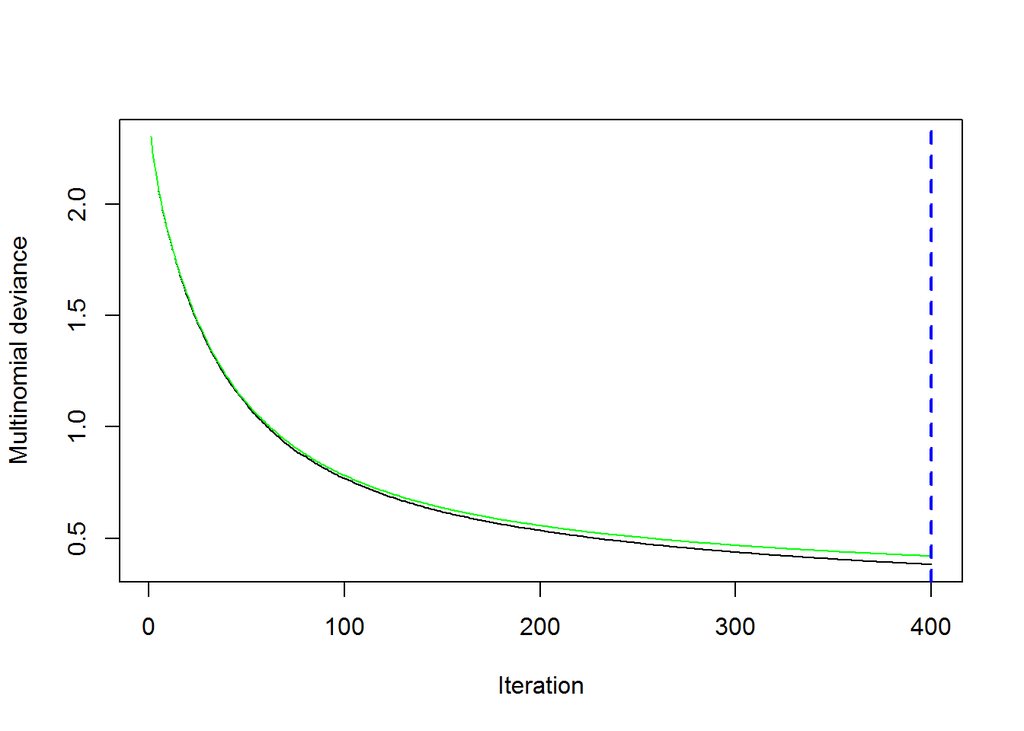

```r
gbm.digit.pred <- predict(gbm.digit.fit, data.frame(test.y, test.x), n.trees = best.iter, type = "response")
gbm.digit.pred <- apply(gbm.digit.pred, 1, which.max)-1
mean(gbm.digit.pred==test.y)
```

```
## [1] 0.8911905
```

Back to top